# R Notebook

# Manual model development - homework

Week 10, day3

```r
kc_house <- read_csv("data/kc_house_data.csv")
```

## Question 1: Tidy up the data ready for regression

```r
kc_tidy <- kc_house %>%
  select(-c(date, id, sqft_living15, sqft_lot15, zipcode))
```

```r
summary(kc_tidy)
```

```
     price            bedrooms        bathrooms      sqft_living       sqft_lot           floors
 Min.   :  75000   Min.   : 0.000   Min.   :0.000   Min.   :  290   Min.   :    520   Min.   :1.000
 1st Qu.: 321950   1st Qu.: 3.000   1st Qu.:1.750   1st Qu.: 1427   1st Qu.:   5040   1st Qu.:1.000
 Median : 450000   Median : 3.000   Median :2.250   Median : 1910   Median :   7618   Median :1.500
 Mean   : 540088   Mean   : 3.371   Mean   :2.115   Mean   : 2080   Mean   :  15107   Mean   :1.494
 3rd Qu.: 645000   3rd Qu.: 4.000   3rd Qu.:2.500   3rd Qu.: 2550   3rd Qu.:  10688   3rd Qu.:2.000
 Max.   :7700000   Max.   :33.000   Max.   :8.000   Max.   :13540   Max.   :1651359   Max.   :3.500
   waterfront            view          condition         grade          sqft_above   sqft_basement
 Min.   :0.000000   Min.   :0.0000   Min.   :1.000   Min.   : 1.000   Min.   : 290   Min.   :   0.0
 1st Qu.:0.000000   1st Qu.:0.0000   1st Qu.:3.000   1st Qu.: 7.000   1st Qu.:1190   1st Qu.:   0.0
 Median :0.000000   Median :0.0000   Median :3.000   Median : 7.000   Median :1560   Median :   0.0
 Mean   :0.007542   Mean   :0.2343   Mean   :3.409   Mean   : 7.657   Mean   :1788   Mean   : 291.5
 3rd Qu.:0.000000   3rd Qu.:0.0000   3rd Qu.:4.000   3rd Qu.: 8.000   3rd Qu.:2210   3rd Qu.: 560.0
 Max.   :1.000000   Max.   :4.0000   Max.   :5.000   Max.   :13.000   Max.   :9410   Max.   :4820.0
    yr_built     yr_renovated         lat             long
 Min.   :1900   Min.   :   0.0   Min.   :47.16   Min.   :-122.5
 1st Qu.:1951   1st Qu.:   0.0   1st Qu.:47.47   1st Qu.:-122.3
 Median :1975   Median :   0.0   Median :47.57   Median :-122.2
 Mean   :1971   Mean   :  84.4   Mean   :47.56   Mean   :-122.2
 3rd Qu.:1997   3rd Qu.:   0.0   3rd Qu.:47.68   3rd Qu.:-122.1
 Max.   :2015   Max.   :2015.0   Max.   :47.78   Max.   :-121.3
```

```r
glimpse(kc_tidy)
```

```
Rows: 21,613
Columns: 16
$ price         <dbl> 221900, 538000, 180000, 604000, 510000, 1225000, 257500, 291850, 229500, 323000, 662500, …
$ bedrooms      <dbl> 3, 3, 2, 4, 3, 4, 3, 3, 3, 3, 3, 2, 3, 3, 5, 4, 3, 4, 2, 3, 4, 3, 5, 2, 3, 3, 3, 3, 3, 4,…
$ bathrooms     <dbl> 1.00, 2.25, 1.00, 3.00, 2.00, 4.50, 2.25, 1.50, 1.00, 2.50, 2.50, 1.00, 1.00, 1.75, 2.00,…
$ sqft_living   <dbl> 1180, 2570, 770, 1960, 1680, 5420, 1715, 1060, 1780, 1890, 3560, 1160, 1430, 1370, 1810, …
$ sqft_lot      <dbl> 5650, 7242, 10000, 5000, 8080, 101930, 6819, 9711, 7470, 6560, 9796, 6000, 19901, 9680, 4…
$ floors        <dbl> 1.0, 2.0, 1.0, 1.0, 1.0, 1.0, 2.0, 1.0, 1.0, 2.0, 1.0, 1.0, 1.5, 1.0, 1.5, 2.0, 2.0, 1.5,…
$ waterfront    <dbl> 0, 0, 0, 0, 0, 0, 0, 0, 0, 0, 0, 0, 0, 0, 0, 0, 0, 0, 0, 0, 0, 0, 0, 0, 0, 0, 0, 0, 0, 0,…
$ view          <dbl> 0, 0, 0, 0, 0, 0, 0, 0, 0, 0, 0, 0, 0, 0, 0, 3, 0, 0, 0, 0, 0, 4, 0, 0, 0, 0, 0, 0, 0, 0,…
$ condition     <dbl> 3, 3, 3, 5, 3, 3, 3, 3, 3, 3, 3, 4, 4, 4, 3, 3, 3, 4, 4, 4, 4, 3, 3, 3, 4, 5, 3, 5, 3, 3,…
$ grade         <dbl> 7, 7, 6, 7, 8, 11, 7, 7, 7, 7, 8, 7, 7, 7, 7, 9, 7, 7, 7, 7, 7, 9, 8, 7, 8, 6, 8, 8, 7, 8…
$ sqft_above    <dbl> 1180, 2170, 770, 1050, 1680, 3890, 1715, 1060, 1050, 1890, 1860, 860, 1430, 1370, 1810, 1…
$ sqft_basement <dbl> 0, 400, 0, 910, 0, 1530, 0, 0, 730, 0, 1700, 300, 0, 0, 0, 970, 0, 0, 0, 0, 760, 720, 0, …
$ yr_built      <dbl> 1955, 1951, 1933, 1965, 1987, 2001, 1995, 1963, 1960, 2003, 1965, 1942, 1927, 1977, 1900,…
$ yr_renovated  <dbl> 0, 1991, 0, 0, 0, 0, 0, 0, 0, 0, 0, 0, 0, 0, 0, 0, 0, 0, 0, 0, 0, 0, 0, 0, 0, 0, 0, 0, 0,…
$ lat           <dbl> 47.5112, 47.7210, 47.7379, 47.5208, 47.6168, 47.6561, 47.3097, 47.4095, 47.5123, 47.3684,…
$ long          <dbl> -122.257, -122.319, -122.233, -122.393, -122.045, -122.005, -122.327, -122.315, -122.337,…
```

```r
kc_tidy <- kc_tidy %>%
  mutate(waterfront = as.logical(waterfront))

head(kc_tidy)
```

| price | bedrooms | bathrooms | sqft_living | sqft_lot | floors | waterfront | view | condition | grade | sqft_above | sqft_basement | yr_built | yr_renovated | lat | long |
| --- | --- | --- | --- | --- | --- | --- | --- | --- | --- | --- | --- | --- | --- | --- | --- |
| 221900 | 3 | 1.00 | 1180 | 5650 | 1 | FALSE | 0 | 3 | 7 | 1180 | 0 | 1955 | 0 | 47.5112 | -122.257 |
| 538000 | 3 | 2.25 | 2570 | 7242 | 2 | FALSE | 0 | 3 | 7 | 2170 | 400 | 1951 | 1991 | 47.7210 | -122.319 |
| 180000 | 2 | 1.00 | 770 | 10000 | 1 | FALSE | 0 | 3 | 6 | 770 | 0 | 1933 | 0 | 47.7379 | -122.233 |
| 604000 | 4 | 3.00 | 1960 | 5000 | 1 | FALSE | 0 | 5 | 7 | 1050 | 910 | 1965 | 0 | 47.5208 | -122.393 |
| 510000 | 3 | 2.00 | 1680 | 8080 | 1 | FALSE | 0 | 3 | 8 | 1680 | 0 | 1987 | 0 | 47.6168 | -122.045 |
| 1225000 | 4 | 4.50 | 5420 | 101930 | 1 | FALSE | 0 | 3 | 11 | 3890 | 1530 | 2001 | 0 | 47.6561 | -122.005 |

```r
kc_tidy <- kc_tidy %>%
  mutate(renovated = if_else(yr_renovated == 0, "not renovated", "renovated"))

head(kc_tidy)
```

| price | bedrooms | bathrooms | sqft_living | sqft_lot | floors | waterfront | view | condition | grade | sqft_above | sqft_basement | yr_built | yr_renovated | lat | long | renovated |
| --- | --- | --- | --- | --- | --- | --- | --- | --- | --- | --- | --- | --- | --- | --- | --- | --- |
| 221900 | 3 | 1.00 | 1180 | 5650 | 1 | FALSE | 0 | 3 | 7 | 1180 | 0 | 1955 | 0 | 47.5112 | -122.257 | not renovated |
| 538000 | 3 | 2.25 | 2570 | 7242 | 2 | FALSE | 0 | 3 | 7 | 2170 | 400 | 1951 | 1991 | 47.7210 | -122.319 | renovated |
| 180000 | 2 | 1.00 | 770 | 10000 | 1 | FALSE | 0 | 3 | 6 | 770 | 0 | 1933 | 0 | 47.7379 | -122.233 | not renovated |
| 604000 | 4 | 3.00 | 1960 | 5000 | 1 | FALSE | 0 | 5 | 7 | 1050 | 910 | 1965 | 0 | 47.5208 | -122.393 | not renovated |
| 510000 | 3 | 2.00 | 1680 | 8080 | 1 | FALSE | 0 | 3 | 8 | 1680 | 0 | 1987 | 0 | 47.6168 | -122.045 | not renovated |
| 1225000 | 4 | 4.50 | 5420 | 101930 | 1 | FALSE | 0 | 3 | 11 | 3890 | 1530 | 2001 | 0 | 47.6561 | -122.005 | not renovated |

```r
kc_tidy <- kc_tidy %>%
  mutate(renovated = recode(renovated, "renovated" = "TRUE",
                            "not renovated" = "FALSE")) %>%
  mutate(renovated = as.logical(renovated))

head(kc_tidy)
```

| price | bedrooms | bathrooms | sqft_living | sqft_lot | floors | waterfront | view | condition | grade | sqft_above | sqft_basement | yr_built | yr_renovated | lat | long | renovated |
| --- | --- | --- | --- | --- | --- | --- | --- | --- | --- | --- | --- | --- | --- | --- | --- | --- |
| 221900 | 3 | 1.00 | 1180 | 5650 | 1 | FALSE | 0 | 3 | 7 | 1180 | 0 | 1955 | 0 | 47.5112 | -122.257 | FALSE |
| 538000 | 3 | 2.25 | 2570 | 7242 | 2 | FALSE | 0 | 3 | 7 | 2170 | 400 | 1951 | 1991 | 47.7210 | -122.319 | TRUE |
| 180000 | 2 | 1.00 | 770 | 10000 | 1 | FALSE | 0 | 3 | 6 | 770 | 0 | 1933 | 0 | 47.7379 | -122.233 | FALSE |
| 604000 | 4 | 3.00 | 1960 | 5000 | 1 | FALSE | 0 | 5 | 7 | 1050 | 910 | 1965 | 0 | 47.5208 | -122.393 | FALSE |
| 510000 | 3 | 2.00 | 1680 | 8080 | 1 | FALSE | 0 | 3 | 8 | 1680 | 0 | 1987 | 0 | 47.6168 | -122.045 | FALSE |
| 1225000 | 4 | 4.50 | 5420 | 101930 | 1 | FALSE | 0 | 3 | 11 | 3890 | 1530 | 2001 | 0 | 47.6561 | -122.005 | FALSE |

```r
kc_tidy <- kc_tidy %>%
  mutate(grade = case_when(grade <= 3 ~ "LOW",
                         grade <= 10 ~ "MEDIUM",
                         grade <= 13 ~ "HIGH"))
head(kc_tidy)
```

| price | bedrooms | bathrooms | sqft_living | sqft_lot | floors | waterfront | view | condition | grade | sqft_above | sqft_basement | yr_built | yr_renovated | lat | long | renovated |
| --- | --- | --- | --- | --- | --- | --- | --- | --- | --- | --- | --- | --- | --- | --- | --- | --- |
| 221900 | 3 | 1.00 | 1180 | 5650 | 1 | FALSE | 0 | 3 | MEDIUM | 1180 | 0 | 1955 | 0 | 47.5112 | -122.257 | FALSE |
| 538000 | 3 | 2.25 | 2570 | 7242 | 2 | FALSE | 0 | 3 | MEDIUM | 2170 | 400 | 1951 | 1991 | 47.7210 | -122.319 | TRUE |
| 180000 | 2 | 1.00 | 770 | 10000 | 1 | FALSE | 0 | 3 | MEDIUM | 770 | 0 | 1933 | 0 | 47.7379 | -122.233 | FALSE |
| 604000 | 4 | 3.00 | 1960 | 5000 | 1 | FALSE | 0 | 5 | MEDIUM | 1050 | 910 | 1965 | 0 | 47.5208 | -122.393 | FALSE |
| 510000 | 3 | 2.00 | 1680 | 8080 | 1 | FALSE | 0 | 3 | MEDIUM | 1680 | 0 | 1987 | 0 | 47.6168 | -122.045 | FALSE |
| 1225000 | 4 | 4.50 | 5420 | 101930 | 1 | FALSE | 0 | 3 | HIGH | 3890 | 1530 | 2001 | 0 | 47.6561 | -122.005 | FALSE |

```r
kc_tidy <- kc_tidy %>%
  mutate(bed_plus_bath = bedrooms + bathrooms, .after = bathrooms)

head(kc_tidy)
```

| price | bedrooms | bathrooms | bed_plus_bath | sqft_living | sqft_lot | floors | waterfront | view | condition | grade | sqft_above | sqft_basement | yr_built | yr_renovated | lat | long | renovated |
| --- | --- | --- | --- | --- | --- | --- | --- | --- | --- | --- | --- | --- | --- | --- | --- | --- | --- |
| 221900 | 3 | 1.00 | 4.00 | 1180 | 5650 | 1 | FALSE | 0 | 3 | MEDIUM | 1180 | 0 | 1955 | 0 | 47.5112 | -122.257 | FALSE |
| 538000 | 3 | 2.25 | 5.25 | 2570 | 7242 | 2 | FALSE | 0 | 3 | MEDIUM | 2170 | 400 | 1951 | 1991 | 47.7210 | -122.319 | TRUE |
| 180000 | 2 | 1.00 | 3.00 | 770 | 10000 | 1 | FALSE | 0 | 3 | MEDIUM | 770 | 0 | 1933 | 0 | 47.7379 | -122.233 | FALSE |
| 604000 | 4 | 3.00 | 7.00 | 1960 | 5000 | 1 | FALSE | 0 | 5 | MEDIUM | 1050 | 910 | 1965 | 0 | 47.5208 | -122.393 | FALSE |
| 510000 | 3 | 2.00 | 5.00 | 1680 | 8080 | 1 | FALSE | 0 | 3 | MEDIUM | 1680 | 0 | 1987 | 0 | 47.6168 | -122.045 | FALSE |
| 1225000 | 4 | 4.50 | 8.50 | 5420 | 101930 | 1 | FALSE | 0 | 3 | HIGH | 3890 | 1530 | 2001 | 0 | 47.6561 | -122.005 | FALSE |

```r
kc_dummy_condition <- kc_tidy %>%
  fastDummies::dummy_cols(select_columns = "condition",
                          remove_first_dummy = TRUE,
                          remove_selected_columns = TRUE)

kc_dummy_condition
```

| price | bedrooms | bathrooms | bed_plus_bath | sqft_living | sqft_lot | floors | waterfront | view | grade | sqft_above | sqft_basement | yr_built | yr_renovated | lat | long | renovated | condition_2 | condition_3 | condition_4 | condition_5 |
| --- | --- | --- | --- | --- | --- | --- | --- | --- | --- | --- | --- | --- | --- | --- | --- | --- | --- | --- | --- | --- |
| 221900 | 3 | 1.00 | 4.00 | 1180 | 5650 | 1.0 | FALSE | 0 | MEDIUM | 1180 | 0 | 1955 | 0 | 47.5112 | -122.257 | FALSE | 0 | 1 | 0 | 0 |
| 538000 | 3 | 2.25 | 5.25 | 2570 | 7242 | 2.0 | FALSE | 0 | MEDIUM | 2170 | 400 | 1951 | 1991 | 47.7210 | -122.319 | TRUE | 0 | 1 | 0 | 0 |
| 180000 | 2 | 1.00 | 3.00 | 770 | 10000 | 1.0 | FALSE | 0 | MEDIUM | 770 | 0 | 1933 | 0 | 47.7379 | -122.233 | FALSE | 0 | 1 | 0 | 0 |
| 604000 | 4 | 3.00 | 7.00 | 1960 | 5000 | 1.0 | FALSE | 0 | MEDIUM | 1050 | 910 | 1965 | 0 | 47.5208 | -122.393 | FALSE | 0 | 0 | 0 | 1 |
| 510000 | 3 | 2.00 | 5.00 | 1680 | 8080 | 1.0 | FALSE | 0 | MEDIUM | 1680 | 0 | 1987 | 0 | 47.6168 | -122.045 | FALSE | 0 | 1 | 0 | 0 |
| 1225000 | 4 | 4.50 | 8.50 | 5420 | 101930 | 1.0 | FALSE | 0 | HIGH | 3890 | 1530 | 2001 | 0 | 47.6561 | -122.005 | FALSE | 0 | 1 | 0 | 0 |
| 257500 | 3 | 2.25 | 5.25 | 1715 | 6819 | 2.0 | FALSE | 0 | MEDIUM | 1715 | 0 | 1995 | 0 | 47.3097 | -122.327 | FALSE | 0 | 1 | 0 | 0 |
| 291850 | 3 | 1.50 | 4.50 | 1060 | 9711 | 1.0 | FALSE | 0 | MEDIUM | 1060 | 0 | 1963 | 0 | 47.4095 | -122.315 | FALSE | 0 | 1 | 0 | 0 |
| 229500 | 3 | 1.00 | 4.00 | 1780 | 7470 | 1.0 | FALSE | 0 | MEDIUM | 1050 | 730 | 1960 | 0 | 47.5123 | -122.337 | FALSE | 0 | 1 | 0 | 0 |
| 323000 | 3 | 2.50 | 5.50 | 1890 | 6560 | 2.0 | FALSE | 0 | MEDIUM | 1890 | 0 | 2003 | 0 | 47.3684 | -122.031 | FALSE | 0 | 1 | 0 | 0 |

[output cut: 990 more lines]

```r
kc_dummy_view <- kc_dummy_condition %>%
  fastDummies::dummy_cols(select_columns = "view",
                          remove_first_dummy = TRUE,
                          remove_selected_columns = TRUE)

kc_dummy_view
```

| price | bedrooms | bathrooms | bed_plus_bath | sqft_living | sqft_lot | floors | waterfront | grade | sqft_above | sqft_basement | yr_built | yr_renovated | lat | long | renovated | condition_2 | condition_3 | condition_4 | condition_5 | view_1 | view_2 | view_3 | view_4 |
| --- | --- | --- | --- | --- | --- | --- | --- | --- | --- | --- | --- | --- | --- | --- | --- | --- | --- | --- | --- | --- | --- | --- | --- |
| 221900 | 3 | 1.00 | 4.00 | 1180 | 5650 | 1.0 | FALSE | MEDIUM | 1180 | 0 | 1955 | 0 | 47.5112 | -122.257 | FALSE | 0 | 1 | 0 | 0 | 0 | 0 | 0 | 0 |
| 538000 | 3 | 2.25 | 5.25 | 2570 | 7242 | 2.0 | FALSE | MEDIUM | 2170 | 400 | 1951 | 1991 | 47.7210 | -122.319 | TRUE | 0 | 1 | 0 | 0 | 0 | 0 | 0 | 0 |
| 180000 | 2 | 1.00 | 3.00 | 770 | 10000 | 1.0 | FALSE | MEDIUM | 770 | 0 | 1933 | 0 | 47.7379 | -122.233 | FALSE | 0 | 1 | 0 | 0 | 0 | 0 | 0 | 0 |
| 604000 | 4 | 3.00 | 7.00 | 1960 | 5000 | 1.0 | FALSE | MEDIUM | 1050 | 910 | 1965 | 0 | 47.5208 | -122.393 | FALSE | 0 | 0 | 0 | 1 | 0 | 0 | 0 | 0 |
| 510000 | 3 | 2.00 | 5.00 | 1680 | 8080 | 1.0 | FALSE | MEDIUM | 1680 | 0 | 1987 | 0 | 47.6168 | -122.045 | FALSE | 0 | 1 | 0 | 0 | 0 | 0 | 0 | 0 |
| 1225000 | 4 | 4.50 | 8.50 | 5420 | 101930 | 1.0 | FALSE | HIGH | 3890 | 1530 | 2001 | 0 | 47.6561 | -122.005 | FALSE | 0 | 1 | 0 | 0 | 0 | 0 | 0 | 0 |
| 257500 | 3 | 2.25 | 5.25 | 1715 | 6819 | 2.0 | FALSE | MEDIUM | 1715 | 0 | 1995 | 0 | 47.3097 | -122.327 | FALSE | 0 | 1 | 0 | 0 | 0 | 0 | 0 | 0 |
| 291850 | 3 | 1.50 | 4.50 | 1060 | 9711 | 1.0 | FALSE | MEDIUM | 1060 | 0 | 1963 | 0 | 47.4095 | -122.315 | FALSE | 0 | 1 | 0 | 0 | 0 | 0 | 0 | 0 |
| 229500 | 3 | 1.00 | 4.00 | 1780 | 7470 | 1.0 | FALSE | MEDIUM | 1050 | 730 | 1960 | 0 | 47.5123 | -122.337 | FALSE | 0 | 1 | 0 | 0 | 0 | 0 | 0 | 0 |
| 323000 | 3 | 2.50 | 5.50 | 1890 | 6560 | 2.0 | FALSE | MEDIUM | 1890 | 0 | 2003 | 0 | 47.3684 | -122.031 | FALSE | 0 | 1 | 0 | 0 | 0 | 0 | 0 | 0 |

[output cut: 990 more lines]

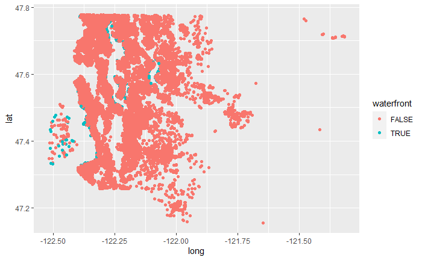

```r
kc_tidy %>%
   ggplot(aes(y = lat, x = long, colour = waterfront))+
geom_point()
```

## 2: Check for aliased variables using the alias() function (this takes in a formula object and a data set). [Hint - formula price ~ . says ‘price varying with all predictors’, this is a suitable input to alias()]. Remove variables that lead to an alias. Check the ‘Elements of multiple regression’ lesson for a dropdown containing further information on finding aliased variables in a dataset.

```r
alias(price ~ ., data = kc_tidy)
```

```
Model :
price ~ bedrooms + bathrooms + bed_plus_bath + sqft_living +
    sqft_lot + floors + waterfront + view + condition + grade +
    sqft_above + sqft_basement + yr_built + yr_renovated + lat +
    long + renovated

Complete :
              (Intercept) bedrooms bathrooms sqft_living sqft_lot floors waterfrontTRUE view condition gradeLOW gradeMEDIUM sqft_above
bed_plus_bath  0           1        1         0           0        0      0              0    0         0        0           0
sqft_basement  0           0        0         1           0        0      0              0    0         0        0          -1
              yr_built yr_renovated lat long renovatedTRUE
bed_plus_bath  0        0            0   0    0
sqft_basement  0        0            0   0    0
```

```r
kc_trim <- kc_tidy %>%
  select(-c(bed_plus_bath, sqft_above, yr_renovated))
```

```r
alias(price ~ ., data = kc_trim)
```

```
Model :
price ~ bedrooms + bathrooms + sqft_living + sqft_lot + floors +
    waterfront + view + condition + grade + sqft_basement + yr_built +
    lat + long + renovated
```

## Task 4: Systematically build a regression model containing up to four main effects (remember, a main effect is just a single predictor with coefficient), testing the regression diagnostics as you go * splitting datasets into numeric and non-numeric columns might help ggpairs() run in manageable time, although you will need to add either a price or resid column to the non-numeric dataframe in order to see its correlations with the non-numeric predictors.

```r
houses_tidy_numeric <- kc_trim %>%
  select_if(is.numeric)
```

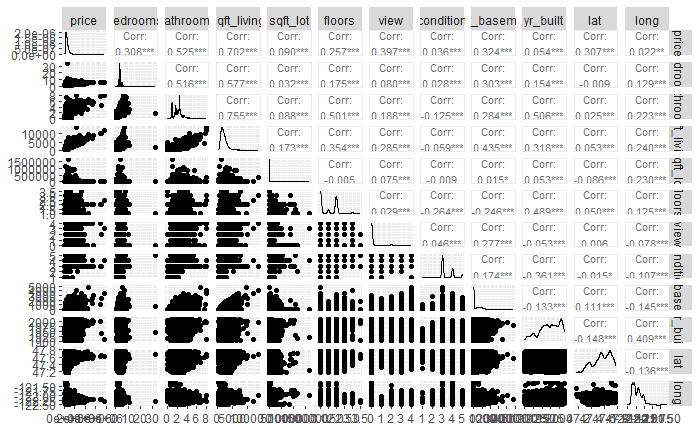

```r
houses_tidy_numeric %>%
  ggpairs(upper = list(continuous = wrap("cor", size = 3)))
```

```r
houses_tidy_nonnumeric <- kc_trim %>%
  select_if(function(x) !is.numeric(x))
houses_tidy_nonnumeric$price <- kc_trim$price
```

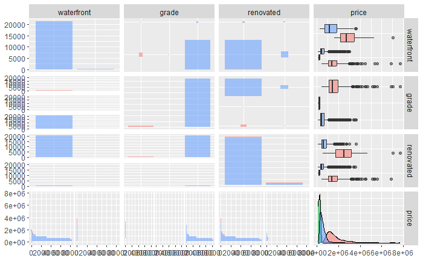

```r
houses_tidy_nonnumeric %>%
  ggpairs(aes(colour = grade, alpha = 0.5))
```

Build a simple linear model for price ~ bathrooms as this has high correlation (0.525)

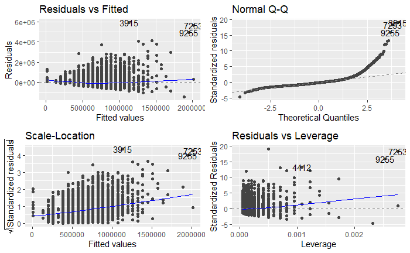

```r
mod1a <- lm(price ~ bathrooms,
            data = kc_trim)

autoplot(mod1a)
```

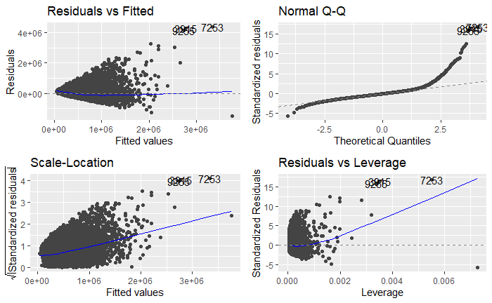

```r
mod1b <- lm(price ~ sqft_living,
            data = kc_trim)

autoplot(mod1b)
```

```r
summary(mod1b)
```

```
Call:
lm(formula = price ~ sqft_living, data = kc_trim)

Residuals:
     Min       1Q   Median       3Q      Max
-1476062  -147486   -24043   106182  4362067

Coefficients:
              Estimate Std. Error t value Pr(>|t|)
(Intercept) -43580.743   4402.690  -9.899   <2e-16 ***
sqft_living    280.624      1.936 144.920   <2e-16 ***
---
Signif. codes:  0 ‘***’ 0.001 ‘**’ 0.01 ‘*’ 0.05 ‘.’ 0.1 ‘ ’ 1

Residual standard error: 261500 on 21611 degrees of freedom
Multiple R-squared:  0.4929,    Adjusted R-squared:  0.4928
F-statistic: 2.1e+04 on 1 and 21611 DF,  p-value: < 2.2e-16
```

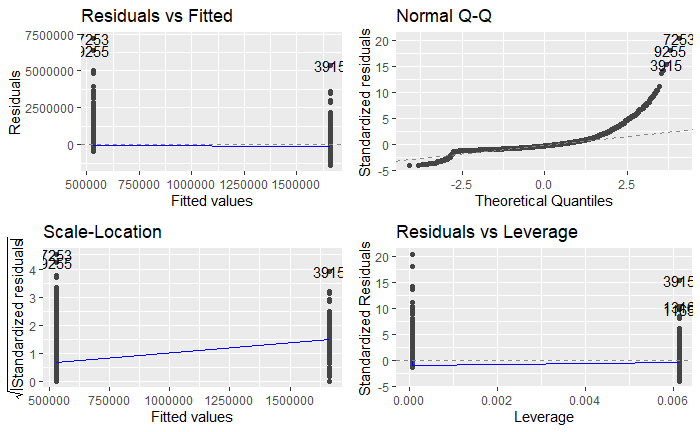

```r
mod1c <- lm(price ~ waterfront,
            data = kc_trim)

autoplot(mod1c)
```

```r
summary(mod1c)
```

```
Call:
lm(formula = price ~ waterfront, data = kc_trim)

Residuals:
     Min       1Q   Median       3Q      Max
-1376876  -211564   -81564   108436  7168436

Coefficients:
               Estimate Std. Error t value Pr(>|t|)
(Intercept)      531564       2416  220.00   <2e-16 ***
waterfrontTRUE  1130312      27823   40.63   <2e-16 ***
---
Signif. codes:  0 ‘***’ 0.001 ‘**’ 0.01 ‘*’ 0.05 ‘.’ 0.1 ‘ ’ 1

Residual standard error: 353900 on 21611 degrees of freedom
Multiple R-squared:  0.07095,   Adjusted R-squared:  0.07091
F-statistic:  1650 on 1 and 21611 DF,  p-value: < 2.2e-16
```

Although sqft_living had a higher correlation, the diagnostic plots looked quite bad, and clearly the model doesn’t fit the data well. So, I went for the second best correlation, bathrooms, and these plots look ok. The QQ plot looks quite bad at one end of the line, but the majority fit the line well.

```r
summary(mod1a)
```

```
Call:
lm(formula = price ~ bathrooms, data = kc_trim)

Residuals:
     Min       1Q   Median       3Q      Max
-1438157  -184525   -41525   113220  5925322

Coefficients:
            Estimate Std. Error t value Pr(>|t|)
(Intercept)    10708       6211   1.724   0.0847 .
bathrooms     250327       2760  90.714   <2e-16 ***
---
Signif. codes:  0 ‘***’ 0.001 ‘**’ 0.01 ‘*’ 0.05 ‘.’ 0.1 ‘ ’ 1

Residual standard error: 312400 on 21611 degrees of freedom
Multiple R-squared:  0.2758,    Adjusted R-squared:  0.2757
F-statistic:  8229 on 1 and 21611 DF,  p-value: < 2.2e-16
```

The R^2 is 0.275 (ie quite low) but it is statistically significant.

### 2nd predictor

Add the residuals to the data and remove the price, bathrooms from the dataset

```r
kc_resid <- kc_trim %>%
  add_residuals(model = mod1a) %>%
  select(-c(price, bathrooms))
```

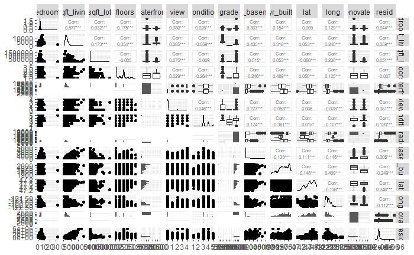

```r
kc_resid %>%
  ggpairs(upper = list(continuous = wrap("cor", size = 2)))
```

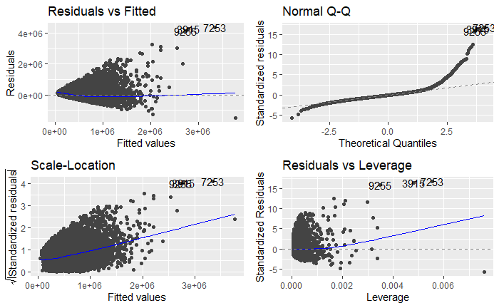

```r
mod2a <- lm(price ~ bathrooms + sqft_living,
            data = kc_trim)

autoplot(mod2a)
```

```r
summary(mod2a)
```

```
Call:
lm(formula = price ~ bathrooms + sqft_living, data = kc_trim)

Residuals:
     Min       1Q   Median       3Q      Max
-1483123  -147387   -24190   105951  4359876

Coefficients:
              Estimate Std. Error t value Pr(>|t|)
(Intercept) -39456.614   5223.129  -7.554 4.38e-14 ***
bathrooms    -5164.600   3519.452  -1.467    0.142
sqft_living    283.892      2.951  96.194  < 2e-16 ***
---
Signif. codes:  0 ‘***’ 0.001 ‘**’ 0.01 ‘*’ 0.05 ‘.’ 0.1 ‘ ’ 1

Residual standard error: 261400 on 21610 degrees of freedom
Multiple R-squared:  0.4929,    Adjusted R-squared:  0.4929
F-statistic: 1.05e+04 on 2 and 21610 DF,  p-value: < 2.2e-16
```

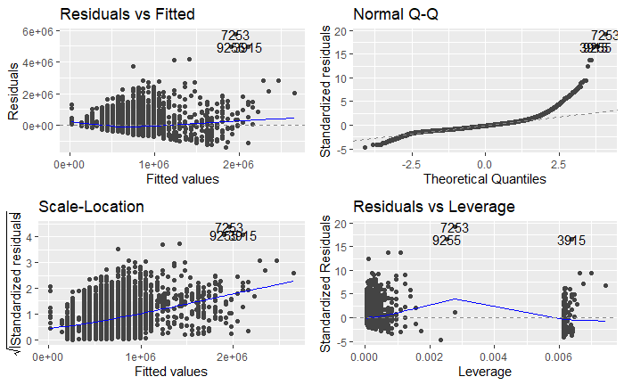

```r
mod2b <- lm(price ~ bathrooms + waterfront,
            data = kc_trim)

autoplot(mod2b)
```

```r
summary(mod2b)
```

```
Call:
lm(formula = price ~ bathrooms + waterfront, data = kc_trim)

Residuals:
     Min       1Q   Median       3Q      Max
-1392408  -178804   -38083   114707  5735981

Coefficients:
               Estimate Std. Error t value Pr(>|t|)
(Intercept)       18251       5975   3.054  0.00226 **
bathrooms        243221       2659  91.464  < 2e-16 ***
waterfrontTRUE   992300      23672  41.919  < 2e-16 ***
---
Signif. codes:  0 ‘***’ 0.001 ‘**’ 0.01 ‘*’ 0.05 ‘.’ 0.1 ‘ ’ 1

Residual standard error: 300500 on 21610 degrees of freedom
Multiple R-squared:  0.3302,    Adjusted R-squared:  0.3302
F-statistic:  5327 on 2 and 21610 DF,  p-value: < 2.2e-16
```

The dignostic plots looks slightly better for sqft_living than previously, but still not very nice. However, the R^2 and p-values are highter than waterfront, so I decided to choose this as the second predictor.

### third predictor

```r
kc_resid2 <- kc_trim %>%
  add_residuals(model = mod2a) %>%
  select(-c(price, bathrooms, sqft_living))
```

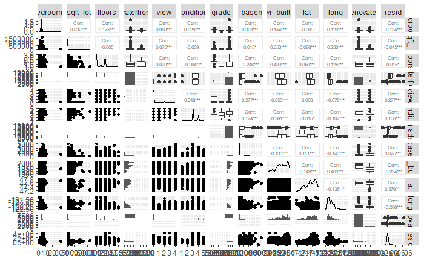

```r
kc_resid2 %>%
  ggpairs(upper = list(continuous = wrap("cor", size = 2)))
```

The variable which previously had a high correlation was the waterfront, view and grade so I will try these in the model and compare

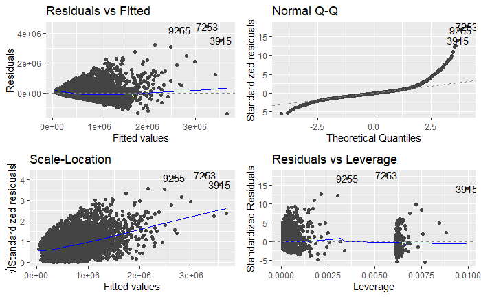

```r
mod3a <- lm(price ~ bathrooms + sqft_living + waterfront,
            data = kc_trim)

autoplot(mod3a)
```

```r
summary(mod3a)
```

```
Call:
lm(formula = price ~ bathrooms + sqft_living + waterfront, data = kc_trim)

Residuals:
     Min       1Q   Median       3Q      Max
-1379551  -142749   -21374   106942  4448376

Coefficients:
                Estimate Std. Error t value Pr(>|t|)
(Intercept)    -31362.13    5028.54  -6.237 4.55e-10 ***
bathrooms       -2002.53    3386.66  -0.591    0.554
sqft_living       273.78       2.85  96.078  < 2e-16 ***
waterfrontTRUE 829719.93   19887.56  41.721  < 2e-16 ***
---
Signif. codes:  0 ‘***’ 0.001 ‘**’ 0.01 ‘*’ 0.05 ‘.’ 0.1 ‘ ’ 1

Residual standard error: 251500 on 21609 degrees of freedom
Multiple R-squared:  0.5307,    Adjusted R-squared:  0.5306
F-statistic:  8146 on 3 and 21609 DF,  p-value: < 2.2e-16
```

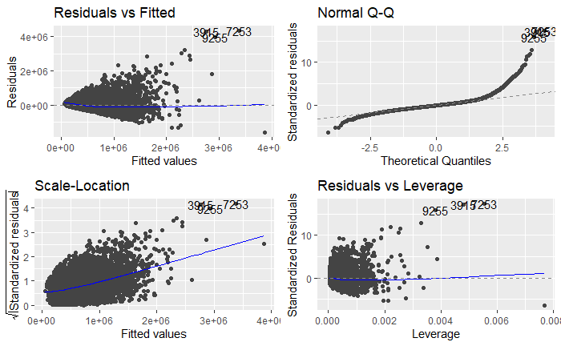

```r
mod3b <- lm(price ~ bathrooms + sqft_living + view,
            data = kc_trim)

autoplot(mod3b)
```

```r
summary(mod3b)
```

```
Call:
lm(formula = price ~ bathrooms + sqft_living + view, data = kc_trim)

Residuals:
     Min       1Q   Median       3Q      Max
-1581868  -139364   -19209   104279  4321608

Coefficients:
              Estimate Std. Error t value Pr(>|t|)
(Intercept) -17861.313   5023.767  -3.555 0.000378 ***
bathrooms     1274.374   3372.334   0.378 0.705515
sqft_living    255.360      2.897  88.133  < 2e-16 ***
view        102988.859   2319.659  44.398  < 2e-16 ***
---
Signif. codes:  0 ‘***’ 0.001 ‘**’ 0.01 ‘*’ 0.05 ‘.’ 0.1 ‘ ’ 1

Residual standard error: 250300 on 21609 degrees of freedom
Multiple R-squared:  0.5353,    Adjusted R-squared:  0.5352
F-statistic:  8297 on 3 and 21609 DF,  p-value: < 2.2e-16
```

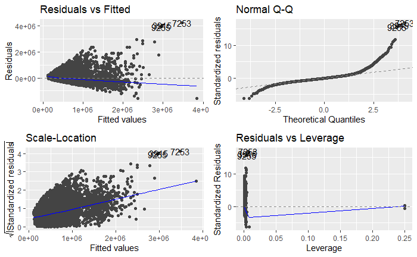

```r
mod3c <- lm(price ~ bathrooms + sqft_living + grade,
            data = kc_trim)

autoplot(mod3c)
```

```r
summary(mod3c)
```

```
Call:
lm(formula = price ~ bathrooms + sqft_living + grade, data = kc_trim)

Residuals:
     Min       1Q   Median       3Q      Max
-1564394  -142271   -24094   101241  4223761

Coefficients:
              Estimate Std. Error t value Pr(>|t|)
(Intercept)  541160.50   14974.31  36.139  < 2e-16 ***
bathrooms       724.47    3393.16   0.214 0.830932
sqft_living     243.09       3.01  80.771  < 2e-16 ***
gradeLOW    -477955.21  126701.27  -3.772 0.000162 ***
gradeMEDIUM -520308.47   12635.67 -41.178  < 2e-16 ***
---
Signif. codes:  0 ‘***’ 0.001 ‘**’ 0.01 ‘*’ 0.05 ‘.’ 0.1 ‘ ’ 1

Residual standard error: 251800 on 21608 degrees of freedom
Multiple R-squared:  0.5298,    Adjusted R-squared:  0.5297
F-statistic:  6087 on 4 and 21608 DF,  p-value: < 2.2e-16
```

Therefore, go with view for the third predictor because the r2 was slightly higher

### fourth predictor

```r
kc_resid3 <- kc_trim %>%
  add_residuals(model = mod3b) %>%
  select(-c(price, bathrooms, sqft_living, -view))
```

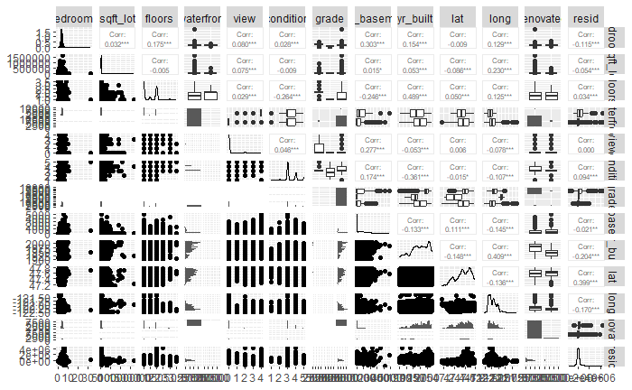

```r
kc_resid3 %>%
  ggpairs(upper = list(continuous = wrap("cor", size = 2)))
View(kc_resid3)
```

Latitude shows high correlation to residuals, let’s add that in next as an option and compare to grade and condition

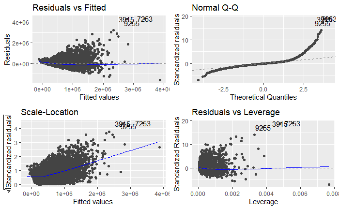

```r
mod4a <- lm(price ~ bathrooms + sqft_living + view + lat,
            data = kc_trim)

autoplot(mod4a)
```

```r
summary(mod4a)
```

```
Call:
lm(formula = price ~ bathrooms + sqft_living + view + lat, data = kc_trim)

Residuals:
     Min       1Q   Median       3Q      Max
-1588997  -115235   -15130    82062  4329726

Coefficients:
              Estimate Std. Error t value Pr(>|t|)
(Intercept) -3.441e+07  5.364e+05 -64.141   <2e-16 ***
bathrooms    5.916e+03  3.092e+03   1.913   0.0557 .
sqft_living  2.464e+02  2.660e+00  92.631   <2e-16 ***
view         1.044e+05  2.126e+03  49.087   <2e-16 ***
lat          7.233e+05  1.128e+04  64.110   <2e-16 ***
---
Signif. codes:  0 ‘***’ 0.001 ‘**’ 0.01 ‘*’ 0.05 ‘.’ 0.1 ‘ ’ 1

Residual standard error: 229400 on 21608 degrees of freedom
Multiple R-squared:  0.6096,    Adjusted R-squared:  0.6095
F-statistic:  8434 on 4 and 21608 DF,  p-value: < 2.2e-16
```

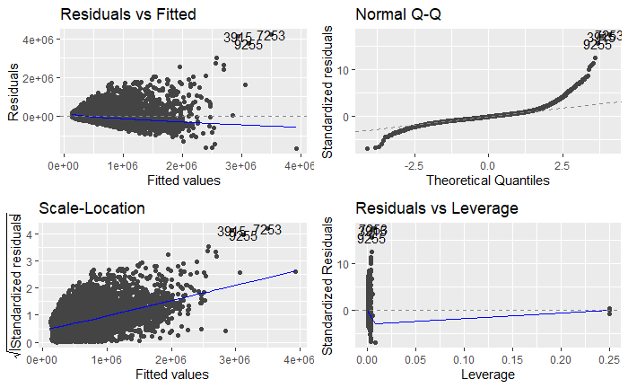

```r
mod4b <- lm(price ~ bathrooms + sqft_living + view + grade,
            data = kc_trim)

autoplot(mod4b)
```

```r
summary(mod4b)
```

```
Call:
lm(formula = price ~ bathrooms + sqft_living + view + grade,
    data = kc_trim)

Residuals:
     Min       1Q   Median       3Q      Max
-1645856  -135616   -20872   101295  4197445

Coefficients:
              Estimate Std. Error t value Pr(>|t|)
(Intercept)  5.204e+05  1.438e+04  36.195  < 2e-16 ***
bathrooms    6.354e+03  3.259e+03   1.950 0.051209 .
sqft_living  2.192e+02  2.941e+00  74.525  < 2e-16 ***
view         9.672e+04  2.245e+03  43.087  < 2e-16 ***
gradeLOW    -4.458e+05  1.216e+05  -3.667 0.000246 ***
gradeMEDIUM -4.835e+05  1.216e+04 -39.779  < 2e-16 ***
---
Signif. codes:  0 ‘***’ 0.001 ‘**’ 0.01 ‘*’ 0.05 ‘.’ 0.1 ‘ ’ 1

Residual standard error: 241600 on 21607 degrees of freedom
Multiple R-squared:  0.567, Adjusted R-squared:  0.5669
F-statistic:  5659 on 5 and 21607 DF,  p-value: < 2.2e-16
```

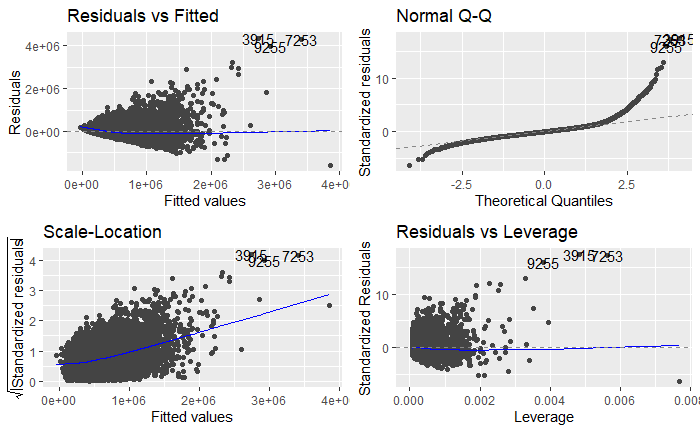

```r
mod4c <- lm(price ~ bathrooms + sqft_living + view + condition,
            data = kc_trim)

autoplot(mod4c)
```

```r
summary(mod4c)
```

```
Call:
lm(formula = price ~ bathrooms + sqft_living + view + condition,
    data = kc_trim)

Residuals:
     Min       1Q   Median       3Q      Max
-1574446  -138641   -19073   105287  4322739

Coefficients:
              Estimate Std. Error t value Pr(>|t|)
(Intercept) -1.528e+05  1.080e+04 -14.147   <2e-16 ***
bathrooms    7.027e+03  3.382e+03   2.078   0.0377 *
sqft_living  2.537e+02  2.887e+00  87.902   <2e-16 ***
view         1.010e+05  2.313e+03  43.662   <2e-16 ***
condition    3.712e+04  2.634e+03  14.095   <2e-16 ***
---
Signif. codes:  0 ‘***’ 0.001 ‘**’ 0.01 ‘*’ 0.05 ‘.’ 0.1 ‘ ’ 1

Residual standard error: 249100 on 21608 degrees of freedom
Multiple R-squared:  0.5395,    Adjusted R-squared:  0.5394
F-statistic:  6329 on 4 and 21608 DF,  p-value: < 2.2e-16
```

I am going to call it a night, not sure if this is correct.

The equation for this model so far is

price = -3.441e+07 + (5.916e+03 * bathrooms) + (2.464e+02 * sqft_living) + (1.044e+05 * view) + ( 7.233e+05 * lat)